FJ

# Feidhelm Joyce

Business & Data Analyst  
Boston, MA

linkedin.com/in/feidhelmjoyce  
github.com/FeidhelmJ

HomeProfessional SummaryMarketing AnalyticsFinancial AnalyticsData Mining for Business AnalyticsCloud AnalyticsProjectsSkillsContact

DATA MINING FOR BUSINESS ANALYTICS

## Classification Trees & Random Forests

← Back to Data Mining for Business Analytics

**I) Topic: Entropy and Cross-Entropy**

```
import numpy as np
import pandas as pd
import matplotlib.pyplot as plt
import seaborn as sns
```

1. Calculate the Shannon entropy for the following discrete random variable with 4 classes: P = [p1,p2,p3,p4] = [0.1,0.3,0.5,0.2] The calculation should be performed using NumPy.

```
P = np.array([0.1, 0.3, 0.5, 0.2])
```

```
entropy = -np.sum(P * np.log2(P))
print("Shannon Entropy:", round(entropy, 4))
```

```
Shannon Entropy: 1.8177
```

2. Calculate the categorical cross-entropy (CCE) loss for the following multi-class classification problem. The true labels are one-hot encoded. For a single sample with C classes.

```
import torch
import torch.nn.functional as F
```

```
y_true = torch.tensor([
    [0, 1, 0],
    [1, 0, 0],
    [0, 0, 1]
], dtype=torch.float32)

y_pred = torch.tensor([
    [0.1, 0.8, 0.1],
    [0.7, 0.2, 0.1],
    [0.05, 0.05, 0.9]
], dtype=torch.float32)
```

```
y_true_idx = torch.argmax(y_true, dim=1)
```

```
loss = F.nll_loss(torch.log(y_pred + 1e-12), y_true_idx)
print("Categorical Cross-Entropy Loss:", round(loss.item(), 4))
```

```
Categorical Cross-Entropy Loss: 0.2284
```

**II) Topic: Classification Tree**

Load the Colleges dataset provided.

```
colleges = pd.read_csv("Colleges.csv", encoding="latin1", skipfooter=1, engine="python")
```

Describe the dataset and provide the summary statistics.

- The dataset contains information on 776 colleges and universities in the United States, each described by 19 variables. Among these, 17 are numeric and 2 are categorical.
- Summary statistics show wide variation across institutions: the average Outstate tuition is about 10,448, Room and Board averages 4,359, and the graduation rate averages 65%. Faculty quality is high on average (73% PhD, 80% Terminal), while application counts are broad with a mean range of around 3,000 - 3,800.

```
colleges.head()
```

|  | Unnamed: 0 | Private | Apps | Accept | Enroll | Top10perc | Top25perc | F.Undergrad | P.Undergrad | Outstate | Room.Board | Books | Personal | PhD | Terminal | S.F.Ratio | perc.alumni | Expend | Grad.Rate |
| --- | --- | --- | --- | --- | --- | --- | --- | --- | --- | --- | --- | --- | --- | --- | --- | --- | --- | --- | --- |
| 0 | Abilene Christian University | Yes | 1660 | 1232 | 721 | 23 | 52 | 2885 | 537 | 7440 | 3300 | 450 | 2200 | 70 | 78 | 18.1 | 12 | 7041 | 60 |
| 1 | Adelphi University | Yes | 2186 | 1924 | 512 | 16 | 29 | 2683 | 1227 | 12280 | 6450 | 750 | 1500 | 29 | 30 | 12.2 | 16 | 10527 | 56 |
| 2 | Adrian College | Yes | 1428 | 1097 | 336 | 22 | 50 | 1036 | 99 | 11250 | 3750 | 400 | 1165 | 53 | 66 | 12.9 | 30 | 8735 | 54 |
| 3 | Agnes Scott College | Yes | 417 | 349 | 137 | 60 | 89 | 510 | 63 | 12960 | 5450 | 450 | 875 | 92 | 97 | 7.7 | 37 | 19016 | 59 |
| 4 | Alaska Pacific University | Yes | 193 | 146 | 55 | 16 | 44 | 249 | 869 | 7560 | 4120 | 800 | 1500 | 76 | 72 | 11.9 | 2 | 10922 | 15 |

```
colleges.tail()
```

|  | Unnamed: 0 | Private | Apps | Accept | Enroll | Top10perc | Top25perc | F.Undergrad | P.Undergrad | Outstate | Room.Board | Books | Personal | PhD | Terminal | S.F.Ratio | perc.alumni | Expend | Grad.Rate |
| --- | --- | --- | --- | --- | --- | --- | --- | --- | --- | --- | --- | --- | --- | --- | --- | --- | --- | --- | --- |
| 771 | Worcester Polytechnic Institute | Yes | 2768 | 2314 | 682 | 49 | 86 | 2802 | 86 | 15884 | 5370 | 530 | 730 | 92 | 94 | 15.2 | 34 | 10774 | 82 |
| 772 | Worcester State College | No | 2197 | 1515 | 543 | 4 | 26 | 3089 | 2029 | 6797 | 3900 | 500 | 1200 | 60 | 60 | 21.0 | 14 | 4469 | 40 |
| 773 | Xavier University | Yes | 1959 | 1805 | 695 | 24 | 47 | 2849 | 1107 | 11520 | 4960 | 600 | 1250 | 73 | 75 | 13.3 | 31 | 9189 | 83 |
| 774 | Xavier University of Louisiana | Yes | 2097 | 1915 | 695 | 34 | 61 | 2793 | 166 | 6900 | 4200 | 617 | 781 | 67 | 75 | 14.4 | 20 | 8323 | 49 |
| 775 | Yale University | Yes | 10705 | 2453 | 1317 | 95 | 99 | 5217 | 83 | 19840 | 6510 | 630 | 2115 | 96 | 96 | 5.8 | 49 | 40386 | 99 |

```
colleges.info()
```

```
<class 'pandas.core.frame.DataFrame'>
RangeIndex: 776 entries, 0 to 775
Data columns (total 19 columns):
 #   Column       Non-Null Count  Dtype
---  ------       --------------  -----
 0   Unnamed: 0   776 non-null    object
 1   Private      776 non-null    object
 2   Apps         776 non-null    int64
 3   Accept       776 non-null    int64
 4   Enroll       776 non-null    int64
 5   Top10perc    776 non-null    int64
 6   Top25perc    776 non-null    int64
 7   F.Undergrad  776 non-null    int64
 8   P.Undergrad  776 non-null    int64
 9   Outstate     776 non-null    int64
 10  Room.Board   776 non-null    int64
 11  Books        776 non-null    int64
 12  Personal     776 non-null    int64
 13  PhD          776 non-null    int64
 14  Terminal     776 non-null    int64
 15  S.F.Ratio    776 non-null    float64
 16  perc.alumni  776 non-null    int64
 17  Expend       776 non-null    int64
 18  Grad.Rate    776 non-null    int64
dtypes: float64(1), int64(16), object(2)
memory usage: 115.3+ KB
```

```
colleges.describe()
```

|  | Apps | Accept | Enroll | Top10perc | Top25perc | F.Undergrad | P.Undergrad | Outstate | Room.Board | Books | Personal | PhD | Terminal | S.F.Ratio | perc.alumni | Expend | Grad.Rate |
| --- | --- | --- | --- | --- | --- | --- | --- | --- | --- | --- | --- | --- | --- | --- | --- | --- | --- |
| count | 776.000000 | 776.000000 | 776.000000 | 776.000000 | 776.000000 | 776.000000 | 776.000000 | 776.000000 | 776.000000 | 776.000000 | 776.000000 | 776.000000 | 776.000000 | 776.000000 | 776.000000 | 776.000000 | 776.000000 |
| mean | 3001.654639 | 2019.015464 | 780.087629 | 27.557990 | 55.787371 | 3700.824742 | 854.176546 | 10447.693299 | 4358.554124 | 549.444588 | 1340.759021 | 72.657216 | 79.708763 | 14.084536 | 22.737113 | 9666.809278 | 65.420103 |
| std | 3872.697557 | 2452.687758 | 929.769965 | 17.651734 | 19.815859 | 4853.481370 | 1523.092275 | 4020.840763 | 1097.029256 | 165.202310 | 677.500299 | 16.338469 | 14.730884 | 3.958278 | 12.398354 | 5221.854692 | 17.146468 |
| min | 81.000000 | 72.000000 | 35.000000 | 1.000000 | 9.000000 | 139.000000 | 1.000000 | 2340.000000 | 1780.000000 | 96.000000 | 250.000000 | 8.000000 | 24.000000 | 2.500000 | 0.000000 | 3186.000000 | 10.000000 |
| 25% | 776.000000 | 603.250000 | 242.000000 | 15.000000 | 41.000000 | 991.000000 | 95.000000 | 7338.000000 | 3597.750000 | 469.500000 | 850.000000 | 62.000000 | 71.000000 | 11.500000 | 13.000000 | 6755.500000 | 53.000000 |
| 50% | 1557.500000 | 1109.500000 | 434.000000 | 23.000000 | 54.000000 | 1707.000000 | 352.500000 | 9990.000000 | 4200.000000 | 500.000000 | 1200.000000 | 75.000000 | 82.000000 | 13.600000 | 21.000000 | 8392.500000 | 65.000000 |
| 75% | 3629.500000 | 2428.000000 | 902.250000 | 35.000000 | 69.000000 | 4030.250000 | 964.000000 | 12931.250000 | 5050.000000 | 600.000000 | 1700.000000 | 85.000000 | 92.000000 | 16.500000 | 31.000000 | 10838.500000 | 78.000000 |
| max | 48094.000000 | 26330.000000 | 6392.000000 | 96.000000 | 100.000000 | 31643.000000 | 21836.000000 | 21700.000000 | 8124.000000 | 2340.000000 | 6800.000000 | 103.000000 | 100.000000 | 39.800000 | 64.000000 | 56233.000000 | 118.000000 |

Create a new variable called yield. Yield is an important metric for colleges – it is the percentage of accepted students who actually enroll in the college. Create this yield variable using two existing variables from the dataset, and then delete the two original variables that you used to create yield.

```
colleges["Yield"] = ((colleges['Enroll']/colleges['Accept'])*100).round(2)
colleges.head()
```

|  | Unnamed: 0 | Private | Apps | Accept | Enroll | Top10perc | Top25perc | F.Undergrad | P.Undergrad | Outstate | Room.Board | Books | Personal | PhD | Terminal | S.F.Ratio | perc.alumni | Expend | Grad.Rate | Yield |
| --- | --- | --- | --- | --- | --- | --- | --- | --- | --- | --- | --- | --- | --- | --- | --- | --- | --- | --- | --- | --- |
| 0 | Abilene Christian University | Yes | 1660 | 1232 | 721 | 23 | 52 | 2885 | 537 | 7440 | 3300 | 450 | 2200 | 70 | 78 | 18.1 | 12 | 7041 | 60 | 58.52 |
| 1 | Adelphi University | Yes | 2186 | 1924 | 512 | 16 | 29 | 2683 | 1227 | 12280 | 6450 | 750 | 1500 | 29 | 30 | 12.2 | 16 | 10527 | 56 | 26.61 |
| 2 | Adrian College | Yes | 1428 | 1097 | 336 | 22 | 50 | 1036 | 99 | 11250 | 3750 | 400 | 1165 | 53 | 66 | 12.9 | 30 | 8735 | 54 | 30.63 |
| 3 | Agnes Scott College | Yes | 417 | 349 | 137 | 60 | 89 | 510 | 63 | 12960 | 5450 | 450 | 875 | 92 | 97 | 7.7 | 37 | 19016 | 59 | 39.26 |
| 4 | Alaska Pacific University | Yes | 193 | 146 | 55 | 16 | 44 | 249 | 869 | 7560 | 4120 | 800 | 1500 | 76 | 72 | 11.9 | 2 | 10922 | 15 | 37.67 |

```
colleges.drop(['Accept', 'Enroll'], axis=1, inplace=True)
colleges.head()
```

|  | Unnamed: 0 | Private | Apps | Top10perc | Top25perc | F.Undergrad | P.Undergrad | Outstate | Room.Board | Books | Personal | PhD | Terminal | S.F.Ratio | perc.alumni | Expend | Grad.Rate | Yield |
| --- | --- | --- | --- | --- | --- | --- | --- | --- | --- | --- | --- | --- | --- | --- | --- | --- | --- | --- |
| 0 | Abilene Christian University | Yes | 1660 | 23 | 52 | 2885 | 537 | 7440 | 3300 | 450 | 2200 | 70 | 78 | 18.1 | 12 | 7041 | 60 | 58.52 |
| 1 | Adelphi University | Yes | 2186 | 16 | 29 | 2683 | 1227 | 12280 | 6450 | 750 | 1500 | 29 | 30 | 12.2 | 16 | 10527 | 56 | 26.61 |
| 2 | Adrian College | Yes | 1428 | 22 | 50 | 1036 | 99 | 11250 | 3750 | 400 | 1165 | 53 | 66 | 12.9 | 30 | 8735 | 54 | 30.63 |
| 3 | Agnes Scott College | Yes | 417 | 60 | 89 | 510 | 63 | 12960 | 5450 | 450 | 875 | 92 | 97 | 7.7 | 37 | 19016 | 59 | 39.26 |
| 4 | Alaska Pacific University | Yes | 193 | 16 | 44 | 249 | 869 | 7560 | 4120 | 800 | 1500 | 76 | 72 | 11.9 | 2 | 10922 | 15 | 37.67 |

Next, convert yield into a factor. Set this up so that any college whose yield value falls at or above the dataset median becomes high yield and all the rest become low yield.

```
median_yield = colleges['Yield'].median()
```

```
colleges['yield_factor'] = colleges['Yield'].apply(lambda x: 'High Yield' if x >= median_yield else 'Low Yield')
colleges['yield_factor'].value_counts()
```

| yield_factor | count |
| --- | --- |
| High Yield | 388 |
| Low Yield | 388 |

Using your assigned seed value (equal to the last 3 digits of you BU Id), partition your data into training (60%) and validation (40%) sets. Show the step(s) that you used to do this.

```
from sklearn.model_selection import train_test_split
```

```
seed_value = 789
np.random.seed(seed_value)
```

```
training_set, test_set = train_test_split(colleges, test_size=0.4, random_state=seed_value)
```

Build a tree model with this dataset, using yield as your outcome variable.

```
from sklearn.tree import DecisionTreeClassifier, plot_tree
from sklearn.metrics import accuracy_score, classification_report
```

```
unnamed_cols_train = [col for col in training_set.columns if col.startswith("Unnamed")]
unnamed_cols_test = [col for col in test_set.columns if col.startswith("Unnamed")]

print("Unnamed columns in training set:", unnamed_cols_train)
print("Unnamed columns in test set:", unnamed_cols_test)
```

```
Unnamed columns in training set: ['Unnamed: 0']
Unnamed columns in test set: ['Unnamed: 0']
```

```
training_set = training_set.drop(columns=unnamed_cols_train, errors='ignore')
test_set = test_set.drop(columns=unnamed_cols_test, errors='ignore')
```

```
X_train = training_set.drop(columns=['yield_factor', 'Yield'], errors='ignore')
y_train = training_set['yield_factor']
```

```
X_test = test_set.drop(columns=['yield_factor', 'Yield'], errors='ignore')
y_test = test_set['yield_factor']
```

```
X_train = pd.get_dummies(X_train, drop_first=True)
X_test  = pd.get_dummies(X_test, drop_first=True)
```

```
X_test = X_test.reindex(columns=X_train.columns, fill_value=0)
```

```
tree_model = DecisionTreeClassifier(max_depth=4, random_state=seed_value)
tree_model.fit(X_train, y_train)
```

```
DecisionTreeClassifier(max_depth=4, random_state=789)
```

If possible, display a classification tree that depicts your model.

```
plt.figure(figsize=(30,15), dpi = 110)
plot_tree(tree_model, feature_names = X_train.columns, class_names = ['Low Yield', 'High Yield'], filled = True,
          rounded = True, fontsize = 12)
plt.title("Classification Tree: Predicting Yield", fontsize = 20, fontweight = 'bold')
plt.show()
```

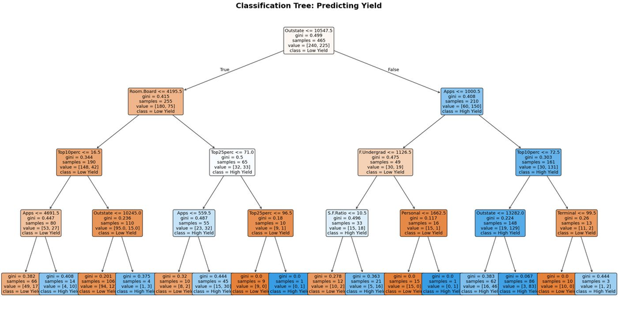

Write a couple of sentences about what you saw with this model.

Did all the input variables from the dataset appear in your model diagram? If not, why not?

- Not all of the input variables from the dataset appear in my decision tree diagram. Variables like Books, perc.alumni, Expend, Grad.Rate, and PhD did not appear in the tree because they did not meaningfully reduce the model’s Gini impurity or improve its predictive accuracy. Decision trees automatically select only the features that provide the greatest information gain, so less influential variables are excluded from the final visualization.

```
X_train.head()
```

|  | Apps | Top10perc | Top25perc | F.Undergrad | P.Undergrad | Outstate | Room.Board | Books | Personal | PhD | Terminal | S.F.Ratio | perc.alumni | Expend | Grad.Rate | Private_Yes |
| --- | --- | --- | --- | --- | --- | --- | --- | --- | --- | --- | --- | --- | --- | --- | --- | --- |
| 534 | 4301 | 41 | 69 | 4892 | 387 | 12772 | 5078 | 576 | 1802 | 74 | 88 | 13.5 | 17 | 12726 | 72 | True |
| 426 | 379 | 15 | 37 | 500 | 311 | 9990 | 4900 | 400 | 600 | 44 | 47 | 12.1 | 26 | 4948 | 33 | True |
| 28 | 662 | 12 | 30 | 2074 | 726 | 11902 | 4372 | 540 | 950 | 65 | 65 | 12.8 | 31 | 7836 | 58 | True |
| 604 | 3235 | 25 | 65 | 9978 | 1530 | 5028 | 3300 | 500 | 2000 | 73 | 89 | 14.8 | 10 | 6820 | 39 | False |
| 7 | 1899 | 37 | 68 | 1594 | 32 | 13868 | 4826 | 450 | 850 | 89 | 100 | 13.7 | 37 | 11487 | 73 | True |

Create confusion matrices to assess the performance of your tree against your training and validation sets. How did it perform?

- The confusion matrices for the decision tree show that the model achieved a training accuracy of 83.2% and a validation/test accuracy of 64.6%. The higher training accuracy indicates that the tree fits the training data well, but the drop in validation accuracy suggests that the model has some overfitting, meaning it learned patterns specific to the training data that did not generalize perfectly to new samples.

```
from sklearn.metrics import confusion_matrix, ConfusionMatrixDisplay, accuracy_score
```

```
y_train_pred = tree_model.predict(X_train)
y_test_pred  = tree_model.predict(X_test)
```

```
print("Training Accuracy:", round(accuracy_score(y_train, y_train_pred), 3))
print("Validation/Test Accuracy:", round(accuracy_score(y_test, y_test_pred), 3))
```

```
Training Accuracy: 0.832
Validation/Test Accuracy: 0.646
```

```
labels = ['Low Yield', 'High Yield']
```

```
cm_train = confusion_matrix(y_train, y_train_pred, labels=labels)
cm_test  = confusion_matrix(y_test, y_test_pred, labels=labels)
```

```
ConfusionMatrixDisplay(cm_train, display_labels= labels).plot(cmap = 'Blues')
plt.title("Training Set Confusion Matrix", fontsize = 15, fontweight = 'bold')
plt.show()
```

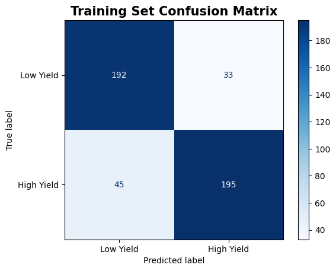

```
ConfusionMatrixDisplay(cm_test, display_labels= labels).plot(cmap = 'Blues')
plt.title("Validation/Test Set Confusion Matrix", fontsize = 15, fontweight = 'bold')
plt.show()
```

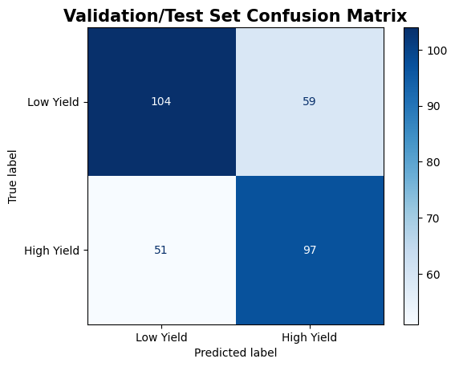

**II) Topic: Random Forest**

1. Use the same dataset as before.
2. Using the same partition as the previous exercise.
3. Build a random forest model with this dataset, using yield as your outcome variable.

```
from sklearn.ensemble import RandomForestClassifier
```

```
random_forest_model = RandomForestClassifier(random_state=seed_value,
                                             n_estimators = 500,
                                             max_depth = 6,
                                             n_jobs = -1)
random_forest_model.fit(X_train, y_train)
```

```
RandomForestClassifier(max_depth=6, n_estimators=500, n_jobs=-1,
                       random_state=789)
```

```
y_train_pred_rf = random_forest_model.predict(X_train)
y_test_pred_rf  = random_forest_model.predict(X_test)
```

```
print("Random Forest Training Accuracy", round(accuracy_score(y_train, y_train_pred_rf), 3))
print("Random Forest Validation/Test Accuracy", round(accuracy_score(y_test, y_test_pred_rf), 3))
```

```
Random Forest Training Accuracy 0.957
Random Forest Validation/Test Accuracy 0.72
```

Create confusion matrices to assess the performance of your model against your training and validation sets. How did it perform?

- The confusion matrices for the random forest model show that it achieved a training accuracy of 95.7% and a validation/test accuracy of 72.0%. The training confusion matrix shows that the model correctly classifies almost all colleges as either high or low yield, while the validation matrix reveals moderate misclassifications but generally good predictive power.

```
cm_train_rf = confusion_matrix(y_train, y_train_pred_rf, labels=labels)
cm_test_rf  = confusion_matrix(y_test, y_test_pred_rf, labels=labels)
```

```
ConfusionMatrixDisplay(cm_train_rf, display_labels= labels).plot(cmap = 'Greens')
plt.title("Random Forest Training Set Confusion Matrix", fontsize = 12, fontweight = 'bold')
plt.show()
```

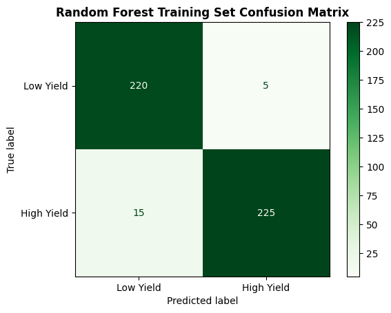

```
ConfusionMatrixDisplay(cm_test_rf, display_labels= labels).plot(cmap = 'Greens')
plt.title("Random Forest Test/Validation Set Confusion Matrix", fontsize = 12, fontweight = 'bold')
plt.show()
```

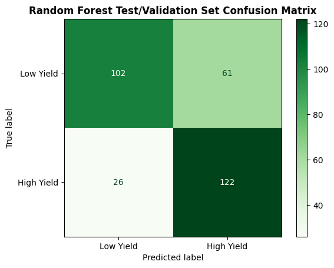

**IV) Topic: Model Comparison**

1. Compare the two models.
2. Which model would you recommend?

Compared to the single decision tree (83.2% training, 64.6% validation), the random forest performed better overall, achieving higher accuracy on both datasets and demonstrating stronger generalization to unseen data. This improvement occurs because the random forest combines the predictions of many decision trees, reducing variance and mitigating overfitting.

Overall, the random forest performed well, balancing model complexity and accuracy, and confirming that using an ensemble of trees provides more robust and reliable yield predictions than a single decision tree.

Therefore, I would recommend the random forest model. It provides more consistent performance, better handles feature variability, and delivers stronger, more reliable predictions of college yield rates.